# Netflix 1990s Movies – Exploratory Case Study

**Author:** Andreza Eufrasio

**Objective:**: Explore Netflix movies released during the 1990s to identify patterns in movie duration, release years, and genres, and examine how these findings could inform content curation and recommendations.

## Dataset:

The analysis uses `netflix_data.csv` from this repository. `release_year` refers to a title's release year, while `date_added` refers to when it was added to Netflix. The dataset includes movies and TV shows; the analysis below filters to movies released from 1990 through 1999. Counts describe titles **in this dataset**, not all movies released worldwide.

| Column | Description |
| --- | --- |
| `show_id` | The ID of the show |
| `type` | Type of show |
| `title` | Title of the show |
| `director` | Director of the show |
| `cast` | Cast of the show |
| `country` | Country of origin |
| `date_added` | Date added to Netflix |
| `release_year` | Year of Netflix release |
| `duration` | Duration of the show in minutes |
| `description` | Description of the show |
| `genre` | Show genre |

We use a Netflix dataset and narrow it to the 1990s, focusing on the fields most relevant to content analysis: **type**, **genre**, **duration**, **release_year**.

## 1) Setup & Data Load

```python
# library
import pandas as pd
import numpy as np
import matplotlib.pyplot as plt


# Expect a file named 'netflix_data.csv' in the same folder.
netflix_df = pd.read_csv("netflix_data.csv")

# Preview dataset
netflix_df.head()
```

|  | show_id | type | title | director | cast | country | date_added | release_year | duration | description | genre |
| --- | --- | --- | --- | --- | --- | --- | --- | --- | --- | --- | --- |
| 0 | s2 | Movie | 7:19 | Jorge Michel Grau | Demián Bichir, Héctor Bonilla, Oscar Serrano, ... | Mexico | December 23, 2016 | 2016 | 93 | After a devastating earthquake hits Mexico Cit... | Dramas |
| 1 | s3 | Movie | 23:59 | Gilbert Chan | Tedd Chan, Stella Chung, Henley Hii, Lawrence ... | Singapore | December 20, 2018 | 2011 | 78 | When an army recruit is found dead, his fellow... | Horror Movies |
| 2 | s4 | Movie | 9 | Shane Acker | Elijah Wood, John C. Reilly, Jennifer Connelly... | United States | November 16, 2017 | 2009 | 80 | In a postapocalyptic world, rag-doll robots hi... | Action |
| 3 | s5 | Movie | 21 | Robert Luketic | Jim Sturgess, Kevin Spacey, Kate Bosworth, Aar... | United States | January 1, 2020 | 2008 | 123 | A brilliant group of students become card-coun... | Dramas |
| 4 | s6 | TV Show | 46 | Serdar Akar | Erdal Beşikçioğlu, Yasemin Allen, Melis Birkan... | Turkey | July 1, 2017 | 2016 | 1 | A genetics professor experiments with a treatm... | International TV |

## 2) Data Quality Checks

> Check the data structure, standardize field names, and validate the variables used in the analysis.

```python
# Normalize column names (common variants across Netflix datasets)

netflix_df.columns = (netflix_df.columns
                      .str.strip().str.lower()
                      .str.replace(r"[ /\-\(\)]+", "_", regex =True)
                      .str.replace(r"_+", "_", regex=True)
                      .str.strip("_")
                     )

print(f" Rows: {netflix_df.shape[0]}  and Columns: {netflix_df.shape[1]}","\n" )
netflix_df.info()
```

```
 Rows: 4812  and Columns: 11

<class 'pandas.core.frame.DataFrame'>
RangeIndex: 4812 entries, 0 to 4811
Data columns (total 11 columns):
 #   Column        Non-Null Count  Dtype
---  ------        --------------  -----
 0   show_id       4812 non-null   object
 1   type          4812 non-null   object
 2   title         4812 non-null   object
 3   director      4812 non-null   object
 4   cast          4812 non-null   object
 5   country       4812 non-null   object
 6   date_added    4812 non-null   object
 7   release_year  4812 non-null   int64
 8   duration      4812 non-null   int64
 9   description   4812 non-null   object
 10  genre         4812 non-null   object
dtypes: int64(2), object(9)
memory usage: 413.7+ KB
```

### Missing Values and Numeric Conversion

Compare missing values before and after coercion to identify values that could not be converted to numbers.

```python
numeric_cols = ["release_year", "duration"]
missing_before = netflix_df[numeric_cols].isna().sum()
netflix_df[numeric_cols] = netflix_df[numeric_cols].apply(
    pd.to_numeric, errors="coerce"
)
missing_after = netflix_df[numeric_cols].isna().sum()
pd.DataFrame({
    "missing_before": missing_before,
    "missing_after": missing_after,
    "new_missing_after_conversion": missing_after - missing_before,
})
```

|  | missing_before | missing_after | new_missing_after_conversion |
| --- | --- | --- | --- |
| release_year | 0 | 0 | 0 |
| duration | 0 | 0 | 0 |

### Placeholder Values and Title Validation

Inspect placeholder values; do not treat a numeric-looking movie title as invalid solely because it is numeric.

```python
placeholders = {"", "?", "n/a", "na", "unknown", "none", "-", "--"}
text_cols = netflix_df.select_dtypes(include=["object", "string", "category"]).columns
placeholder_counts = {
    col: netflix_df[col].astype("string").str.strip().str.lower()
        .isin(placeholders).sum()
    for col in text_cols
}
pd.Series(placeholder_counts, name="placeholder_count").loc[lambda s: s > 0]
```

```
title    1
Name: placeholder_count, dtype: int64
```

```python
# Inspect missing or placeholder titles before deciding whether to remove them.
invalid_title = (
    netflix_df["title"].isna()
    | netflix_df["title"].astype("string").str.strip().str.lower().isin(placeholders)
)
print("Missing/placeholder titles:", int(invalid_title.sum()))
netflix_df.loc[invalid_title, ["show_id", "type", "title", "release_year", "duration", "genre"]]
```

```
Missing/placeholder titles: 1
```

|  | show_id | type | title | release_year | duration | genre |
| --- | --- | --- | --- | --- | --- | --- |
| 4562 | s7352 | Movie | Unknown | 2011 | 113 | Action |

> Only rows with missing or explicitly recognized placeholder titles are excluded; valid numeric movie titles are retained.

```python
netflix_df = netflix_df.loc[~invalid_title].copy()
print(f"Rows removed for missing/placeholder titles: {int(invalid_title.sum())}")
print("Exact duplicate rows:", int(netflix_df.duplicated().sum()))
print("Potential duplicate titles (review before removing):",
      int(netflix_df.duplicated(subset=["title", "genre", "release_year", "duration", "type"]).sum()))
print("Release-year range:", netflix_df["release_year"].min(), "to", netflix_df["release_year"].max())
print("Duration range:", netflix_df["duration"].min(), "to", netflix_df["duration"].max())
```

```
Rows removed for missing/placeholder titles: 1
Exact duplicate rows: 0
Potential duplicate titles (review before removing): 0
Release-year range: 1942 to 2021
Duration range: 1 to 253
```

## 3) 1990s Movie Subset

> Restrict the dataset to movies released between 1990 and 1999. Exclude records with missing or nonpositive movie duration from runtime-based analyses.

```python
movies_90_df = netflix_df.loc[
    netflix_df["type"].eq("Movie")
    & netflix_df["release_year"].between(1990, 1999)
].copy()
print(f"1990s movies in dataset: {len(movies_90_df)}")
print("Missing or nonpositive durations:",
      int((movies_90_df["duration"].isna() | movies_90_df["duration"].le(0)).sum()))
valid_runtime_df = movies_90_df.loc[movies_90_df["duration"].gt(0)].copy()
movies_90_df["release_year"].value_counts().sort_index()
```

```
1990s movies in dataset: 183
Missing or nonpositive durations: 0
```

```
release_year
1990    14
1991    14
1992    16
1993    16
1994    14
1995    16
1996    15
1997    26
1998    26
1999    26
Name: count, dtype: int64
```

## 4) Q1 — What was the most frequent movie duration in the 1990s?

> Use the mode of valid movie durations; show the distribution for context.

```
Most frequent duration(s) (minutes): [94]
Titles at each modal duration: 7
```

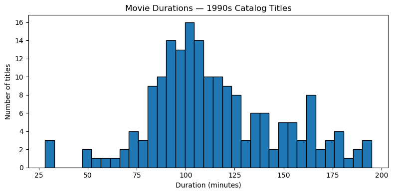

```python
duration_counts = valid_runtime_df["duration"].value_counts()
most_frequent_durations = duration_counts.loc[lambda s: s.eq(s.max())].index.tolist()
print("Most frequent duration(s) (minutes):", most_frequent_durations)
print("Titles at each modal duration:", int(duration_counts.max()))

ax = valid_runtime_df["duration"].plot.hist(bins=35, edgecolor="black", figsize=(8, 4))
ax.set(title="Movie Durations — 1990s Catalog Titles", xlabel="Duration (minutes)", ylabel="Number of titles")
plt.tight_layout()

# Save the chart as a PNG image
plt.savefig("movie_duration_1990s.png", dpi=300, bbox_inches="tight")

plt.show()
```

### Insights

- The most frequent movie duration was **94 minutes**, appearing in 7 titles in the 1990s subset of the Netflix dataset.
- The histogram shows a concentration of movie durations around 90–110 minutes, although the dataset includes both shorter and longer movies.
- The mode represents the most frequently occurring exact duration, rather than the average runtime or a preferred movie length.

### Recommendations

- **Editorial Curation:** Create a collection such as *"Classic 90-Minute 90s Films"* to help viewers discover movies within a similar runtime range.
- **Duration-Based Filtering:** Consider organizing 1990s movies into runtime categories, such as under 90 minutes, 90–120 minutes, and over 120 minutes, to make browsing by movie length easier.

### Final Answer

The most frequent movie duration among Netflix movies released in the 1990s was **94 minutes**, appearing in 7 titles.

> Count movies labeled `Action` with a duration under 90 minutes. Report both the share of all 1990s movies and the share of Action movies.

```python
action_df = valid_runtime_df.loc[valid_runtime_df["genre"].eq("Action")]
short_action_df = action_df.loc[action_df["duration"].lt(90)]
short_action_count = len(short_action_df)
print("Short Action movies:", short_action_count)
print(f"Share of all 1990s movies: {short_action_count / len(movies_90_df):.1%}" if len(movies_90_df) else "No 1990s movies")
print(f"Share of Action movies with valid durations: {short_action_count / len(action_df):.1%}" if len(action_df) else "No Action movies")
```

```
Short Action movies: 7
Share of all 1990s movies: 3.8%
Share of Action movies with valid durations: 14.6%
```

### Insights

- There are **7 short Action movies** (less than 90 minutes) in the 1990s Netflix dataset.
- These movies represent approximately **3.8% of all 1990s movies** (7 out of 183).
- Short Action movies represent a small segment of the 1990s catalog analyzed.

### Recommendations

- **Editorial Curation:** Create a collection such as *"Quick-Watch 90s Action Movies"* to help viewers discover shorter Action films.
- **Duration-Based Filtering:** Allow viewers to filter Action movies by runtime to make it easier to find movies that fit their available viewing time.

### Final Answer

The number of short Action movies (less than 90 minutes) released in the 1990s in the Netflix dataset was **7**.

## 6) Q3 — Which year(s) in the 1990s had the most movie releases?

```
Peak year(s) and counts:
release_year
1997    26
1998    26
1999    26
Name: count, dtype: int64
```

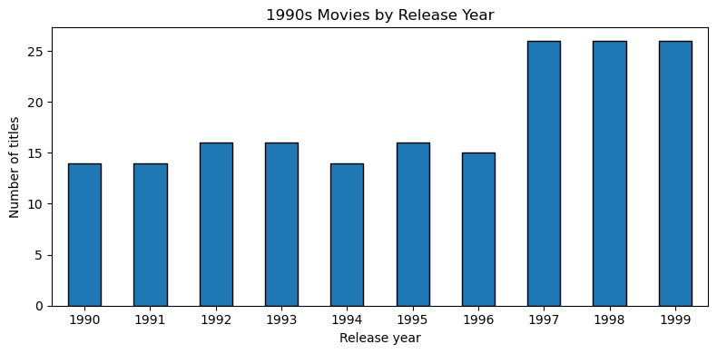

```python
year_counts = movies_90_df["release_year"].value_counts().sort_index()
peak_years = year_counts[year_counts.eq(year_counts.max())]

print("Peak year(s) and counts:")
print(peak_years)

ax = year_counts.plot.bar(figsize=(8, 4), edgecolor="black")
ax.set(title="1990s Movies by Release Year", xlabel="Release year", ylabel="Number of titles")
plt.xticks(rotation=0)
plt.tight_layout()

# Save the figure
plt.savefig("1990s_movies_by_release_year.png", dpi=300, bbox_inches="tight")

plt.show()
```

### Insights

- The years **1997, 1998, and 1999** had the highest number of movie releases in the 1990s Netflix dataset, with **26 titles each**.
- From 1990 to 1996, the number of movies released each year ranged from 14 to 16, followed by an increase to 26 movies per year from 1997 to 1999.
- The late 1990s (1997–1999) accounted for the largest share of movie releases in the dataset.

### Recommendations

- **Editorial Curation:** Create a collection featuring movies from 1997–1999 to highlight the most represented release years in the 1990s catalog.
- **Nostalgic Promotions:** Develop themed collections such as *"Late 90s Movie Classics"* to help viewers discover titles from this period.

### Final Answer

The years **1997, 1998, and 1999** had the most movie releases in the 1990s Netflix dataset, with **26 movies each**.

## 7) Q4 — Which genres dominated the decade?

> Count titles by the genre label supplied in the dataset.

```
genre
Action            48
Dramas            44
Comedies          40
Children          15
Classic Movies    15
Stand-Up           8
Thrillers          5
Horror Movies      4
Documentaries      2
Cult Movies        2
Name: count, dtype: int64
Top three genres:

genre
Action      48
Dramas      44
Comedies    40
Name: count, dtype: int64
```

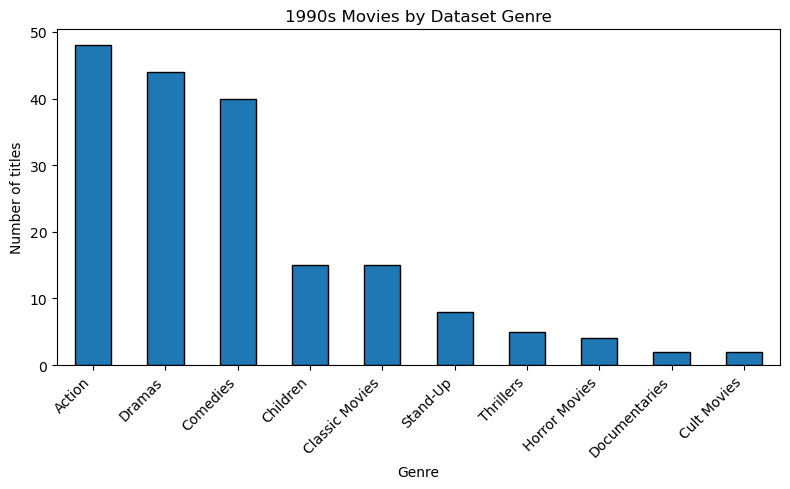

```python
genre_counts = movies_90_df["genre"].value_counts()
print(genre_counts)
print("Top three genres:")
print()
print(genre_counts.head(3))

ax = genre_counts.plot.bar(figsize=(8, 5), edgecolor="black")
ax.set(title="1990s Movies by Dataset Genre", xlabel="Genre", ylabel="Number of titles")
plt.xticks(rotation=45, ha="right")
plt.tight_layout()

# Save the figure
plt.savefig("1990s_movies_by_dataset_genre.png", dpi=300, bbox_inches="tight")

plt.show()
```

### Insights

- The three most represented genres in the 1990s Netflix dataset were **Action (48 movies)**, **Drama (44 movies)**, and **Comedy (40 movies)**.
- Together, these three genres accounted for **132 of the 183 movies (72.1%)** in the dataset, representing the majority of the 1990s catalog analyzed.
- Other categories, such as Children (15), Classic Movies (15), and Stand-Up (8), had lower representation.
- Thrillers (5), Horror Movies (4), Documentaries (2), and Cult Movies (2) were among the least represented genres in the dataset.

### Recommendations

- **Editorial Curation:** Feature Action, Drama, and Comedy prominently in 1990s movie collections, reflecting their strong representation in the dataset.
- **Niche Genre Discovery:** Create themed collections featuring less represented genres, such as Thrillers, Horror Movies, and Documentaries, to help viewers discover a wider variety of 1990s movies.

### Final Answer

The most represented genres in the 1990s Netflix dataset were **Action (48 movies), Drama (44 movies), and Comedy (40 movies)**, accounting for approximately **72.1% of the movies analyzed**.

## 8) Q5 — Were any content gaps identified?

> For this case study, define less represented as a genre with fewer titles than the median count across observed genre labels. This is a descriptive threshold, not evidence of unmet audience demand.

```
Mean number of titles per genre: 18.3
Median number of titles per genre: 11.5

Genres below the median:
genre
Stand-Up         8
Thrillers        5
Horror Movies    4
Documentaries    2
Cult Movies      2
Name: count, dtype: int64
```

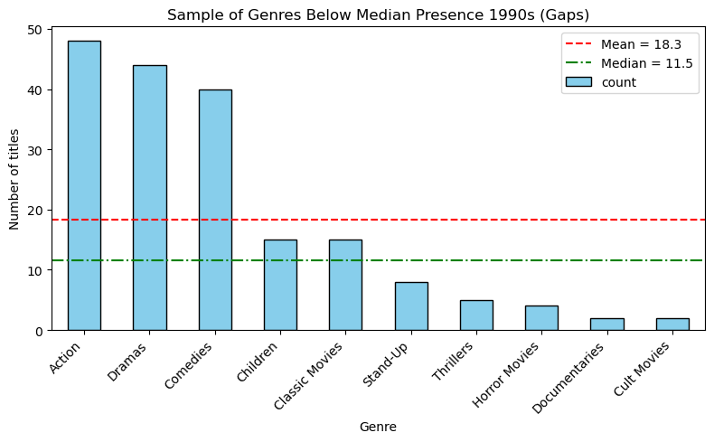

```python
# Count movies per genre
genre_counts = movies_90_df["genre"].value_counts()

# Calculate mean and median
mean_count = genre_counts.mean()
median_count = genre_counts.median()

# Identify genres below the median
less_represented = genre_counts[
    genre_counts < median_count
]

print(f"Mean number of titles per genre: {mean_count:.1f}")
print(f"Median number of titles per genre: {median_count:.1f}")

print("\nGenres below the median:")
print(less_represented)

# Plot genre distribution
ax = genre_counts.plot.bar(
    figsize=(8, 5),
    color="skyblue",
    edgecolor="black"
)

# Add mean and median reference lines
ax.axhline(
    mean_count,
    color="red",
    linestyle="--",
    label=f"Mean = {mean_count:.1f}"
)

ax.axhline(
    median_count,
    color="green",
    linestyle="-.",
    label=f"Median = {median_count:.1f}"
)

ax.set(
    title="Sample of Genres Below Median Presence 1990s (Gaps)",
    xlabel="Genre",
    ylabel="Number of titles"
)

ax.legend()
plt.xticks(rotation=45, ha="right")
plt.tight_layout()

# Save the figure
plt.savefig(
    "1990s_genre_representation.png",
    dpi=300,
    bbox_inches="tight"
)

# Save the figure
plt.savefig("Sample of Genres Below Median Presence 1990s (Gaps).png", dpi=300, bbox_inches="tight")
plt.show()
```

### Insights

- The mean number of movies per genre was **18.3**, while the median was **11.5**, reflecting the relatively high representation of Action, Drama, and Comedy in the dataset.
- Five genres fell below the median: Stand-Up (8), Thrillers (5), Horror Movies (4), Documentaries (2), and Cult Movies (2).
- Documentaries and Cult Movies had the lowest representation, with only 2 titles each.
- These findings identify potential content gaps in the analyzed Netflix catalog but do not establish unmet audience demand.

### Recommendations

- **Genre Discovery:** Create themed collections featuring less-represented genres, such as Thrillers, Horror Movies, and Documentaries, to improve their visibility.
- **Content Diversity:** Consider exploring additional titles in less-represented genres when evaluating opportunities to expand the catalog. Audience demand and viewing behavior should be assessed before making acquisition decisions.

### Final Answer

Yes. Based on the median threshold of 11.5 movies per genre, five genres were identified as potential content gaps in the 1990s Netflix dataset: **Stand-Up (8), Thrillers (5), Horror Movies (4), Documentaries (2), and Cult Movies (2)**.

## 9) Findings & Next Steps

### Summary of Insights

This exploratory analysis examined Netflix movies released during the 1990s, focusing on movie duration, release years, and genre representation.

- **Most frequent runtime:** 94 minutes was the most common movie duration, appearing in 7 titles.
- **Short Action movies:** Only 7 Action movies were shorter than 90 minutes, representing approximately 3.8% of the 183 movies analyzed.
- **Peak release years:** 1997, 1998, and 1999 had the highest number of movie releases, with 26 titles each.
- **Top genres:** Action (48), Drama (44), and Comedy (40) accounted for approximately 72.1% of the movies analyzed.
- **Potential content gaps:** Five genres fell below the median genre count of 11.5 movies: Stand-Up (8), Thrillers (5), Horror Movies (4), Documentaries (2), and Cult Movies (2).

### Potential Applications

The findings suggest several opportunities for organizing and exploring the 1990s Netflix catalog:

- **Duration-Based Collections:** Create collections of approximately 90-minute movies and short Action films to help viewers discover titles based on their available viewing time.
- **Nostalgic Curation:** Highlight movies released between 1997 and 1999 through themed collections featuring late-1990s titles.
- **Genre Discovery:** Feature Action, Drama, and Comedy in 1990s collections while creating dedicated sections for less-represented genres to improve their visibility.

### Limitations & Next Steps

This analysis focuses on movies available in the Netflix dataset and does not represent all movies released worldwide during the 1990s.

The findings describe patterns in movie duration, release years, and genre representation within the analyzed catalog.

Future analysis could incorporate audience ratings and viewing trends to explore movie popularity and viewer preferences.

Back to top